# Reproducible Research: Peer Assessment 1

## 1.0 Introduction

This assignment makes use of data from a personal activity monitoring device. This device collects data at 5 minute intervals through out the day. The data consists of two months of data from an anonymous individual collected during the months of October and November, 2012 and include the number of steps taken in 5 minute intervals each day.

The data for this assignment can be downloaded here: https://d396qusza40orc.cloudfront.net/repdata%2Fdata%2Factivity.zip

## 2.0 Loading and Preprocessing the Data

### 2.1 Global options and load package

Global option for echo is set to TRUE to show code chunks in the report. For this analysis, we are using the dplyr and ggplot2 packages.

```r
knitr::opts_chunk$set(echo = TRUE, eval = TRUE)
library(dplyr)
library(ggplot2)
```

### 2.2 Get the Dataset

The dataset is available in the repository in zip format. Data is then unzipped and saved in the same directory. Then load the dataset onto R.

```r
if(!file.exists("activity.csv")){
zipF <- "activity.zip"
unzip(zipF)
rm(list = ls())}
df <- read.csv("activity.csv")
```

### 2.3 Preprocess Data

Convert the date variable to class “Date” and remove all rows with NAs for later analysis.

```r
df$date <- as.Date(df$date)
df_rm_na <- df[complete.cases(df),]
df_sum <- df_rm_na %>% group_by(date) %>% summarise(steps = sum(steps))
```

## 3.0 Steps Taken Daily

### 3.1 Plot Histogram

First, calculate total number of steps taken each day (group data by date). Note that data without NAs is used for this analysis.

```r
df_sum <- df_rm_na %>% group_by(date) %>% summarise(steps = sum(steps))
```

Next, use the total number of steps taken each day to plot the histogram.

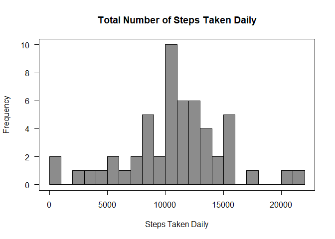

```r
hist(x = df_sum$steps,
         main = "Total Number of Steps Taken Daily",
         xlab = "Steps Taken Daily", ylab = "Frequency",
         col = rgb(0.1,0.1,0.1,0.5), breaks = 20, las = 1)
box()
```

### 3.2 Calculate Mean and Median

Mean and median of total steps taken each day are calculated below:

```r
mean(df_sum$steps)
```

```
## [1] 10766.19
```

```r
median(df_sum$steps)
```

```
## [1] 10765
```

## 4.0 Average Daily Activity Pattern

### 4.1 Average Steps per Interval

Calculate average steps at every interval across all dates.

```r
df_interval <- df_rm_na %>% group_by(interval) %>%
        summarise(steps = mean(steps)) %>% as.data.frame
```

### 4.2 Create Time Series Plot

Make a time series plot of the 5-minute interval (x-axis) and the average number of steps taken across all days (y-axis).

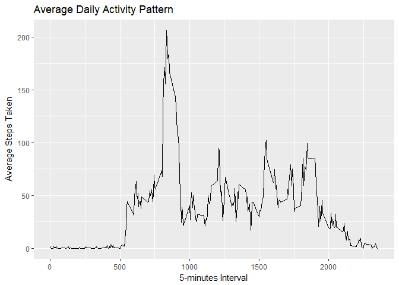

```r
ggplot(df_interval, aes(df_interval$interval, df_interval$steps)) + geom_line() +
        xlab("5-minutes Interval") + ylab("Average Steps Taken") +
        ggtitle("Average Daily Activity Pattern")
```

### 4.3 Interval with maximum number of steps

```r
df_interval[df_interval$steps==max(df_interval$steps),1]
```

```
## [1] 835
```

## 5.0 Handling Missing Values (NAs)

### 5.1 Calculate no of rows with missing values(NA)

```r
sum_na <- sum(is.na(df))
```

No. of rows with missing values is 2304.

### 5.2 Replace NA with number of average steps across all days

All missing values in steps column are replaced by number of average steps for the same interval. Firstly, dataset containing only rows with NAs is extracted and merged with dataset with average steps across all days (df_interval) by matching the interval column. The resulting dataset is then joined with dataset without NAs (df_rm_na) to create a complete dataset.

```r
df_na <- df[is.na(df$steps),]
dft <- merge(df_na, df_interval, by.x = "interval", by.y = "interval")
colnames(dft)[4] <- c("steps")
dft$steps.x = dft$steps
dft <- dft[c("steps", "date", "interval")]
df_new <- rbind(dft,df_rm_na)
df_new <- arrange(df_new, date, interval)
```

### 5.3 Calculate Mean and Median Using New Dataset

Mean and median of total steps taken each day using the new dataset are:

```r
df_new_sum <- df_new %>% group_by(date) %>% summarise(steps = sum(steps))
mean(df_new_sum$steps)
```

```
## [1] 10766.19
```

```r
median(df_new_sum$steps)
```

```
## [1] 10766.19
```

### 5.4 Plot Histogram to Compare Dataset with NAs Removed with New Dataset

Create two histogram on the same plot using dataset with NAs removed (refer section 3) and the new dataset (refer section 5) to compare the data.

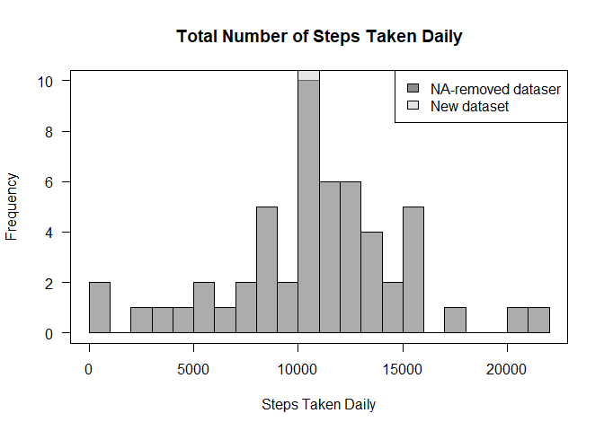

```r
hist(df_sum$steps, main = "Total Number of Steps Taken Daily",
             xlab = "Steps Taken Daily", ylab = "Frequency",
             col=rgb(0.1,0.1,0.1,0.5), breaks = 20, las = 1)
hist(df_new_sum$steps, col=rgb(0.8,0.8,0.8,0.5), breaks = 20, ylim = c(0,20), add=T)
legend("topright", c("NA-removed dataser", "New dataset"), fill=c(rgb(0.1,0.1,0.1,0.5), rgb(0.8,0.8,0.8,0.5)))
box()
```

## 6.0 Activity Pattern during “Weekdays” and “Weekends”

### 6.1 Add “day type” Variable" to New Dataset

A “day” variable with value “weekday” or “weekend” is added to the new dataset.

```r
df_day <- df_new %>% mutate(day = weekdays(df_new$date)) %>%
        mutate(day = ifelse(day==c("Saturday", "Sunday"), "weekend", "weekday"))
```

### 6.2 Calculate Average Steps for Every Interval during Weekdays and Weekends

Dataset is grouped into day type and interval to calculate the average steps.

```r
df_interval_day <- df_day %>% group_by(day, interval) %>%
        summarise(steps = mean(steps)) %>% as.data.frame
```

### 6.3 Create Time Series Plot for Average Steps Taken on Weekends and Weekdays

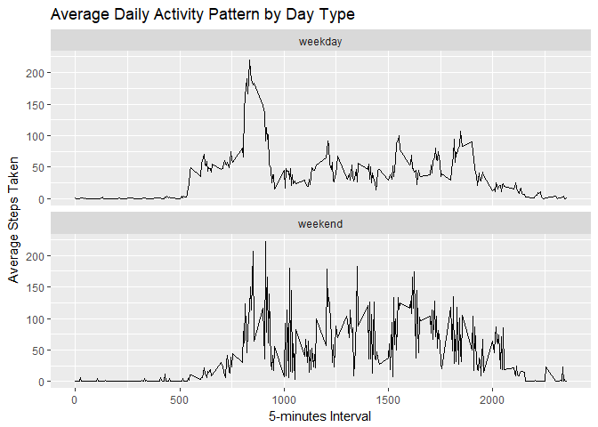

```r
timeplot2 <- ggplot(df_interval_day,
                    aes(df_interval_day$interval, df_interval_day$steps)) +
        geom_line() + xlab("5-minutes Interval") + ylab("Average Steps Taken") +
        ggtitle("Average Daily Activity Pattern by Day Type")

timeplot2 + facet_wrap(~day, ncol = 1)
```